# Two amplifier RIAA phono preamp

Last update: 17 Nov 2023

## Abstract

the use of modern computer codes makes the math and algebra amost trival, but still need to know what youer doing.

**Contents**  
1. Introduction  
2. RIAA pre-emphasis curve  
3. AN-346 RIAA Phono Preamplifier Design Procedure  
4. Analysis of the phono preamplifier circuit  
5. Alternate designs  
6. Summary

**License:** This work (includes python code, documentation, test circuits, etc.) is licensed under a [Creative Commons Attribution-ShareAlike 4.0 International License](https://creativecommons.org/licenses/by-sa/4.0/).  
Share — copy and redistribute the material in any medium or format  
Adapt — remix, transform, and build upon the material for any purpose, even commercially.

## Scope

- highlight use of python for circuit analysis
- not to design a preamp

## 1) Introduction

- what why and how?
- show case the use of python in electrical engineering

An application of the LM833 is the two stage RIAA Phono Preamplifier. A primary task of the phono preamplifier is to provide gain (usually 30 to 40 dB at 1 kHz) and accurate amplitude and phase equalization to the signal from a moving magnet or a moving coil cartridge. In addition to the amplification and equalization functions, the phono preamp must not add significant noise or distortion to the signal from the cartridge. The circuit shown in Figure 36 uses two amplifiers, fulfills these qualifications, and has greatly improved performance over a single- amplifier design.

What is a Phono Preamp and Why Do I Need One? A phono preamplifier, also known as a phono stage, is an audio component that amplifies the signal from your turntable to a level that allows you to connect it to your sound system the same way you would with any other audio source.

Another important job of a phono preamp is to apply the RIAA equalization curve to the signal, reverting it back to the shape it was on the original recording, but if you’re just starting out, this may be a bit deeper than you need to go right now. The most important thing to know is that you will need a phono preamp in order to enjoy your vinyl records.

With the resurgence of vinyl over the last several years, a whole new generation is getting into turntables. With so much “plug and play” technology, we find that people who are younger or have never used a turntable before expect that a turntable will just play, or at least simply connect to their existing stereo system or speakers.

popularity of Vinyl LP records

[They Said the Album Was Dying. They Were Wrong](https://www.billboard.com/pro/album-format-dead-narrative-music-discovery-tiktok-singles/)

> Vinyl sales have grown steadily for 17 years, but jumped by a stunning 46% in 2020 and 51% in 2021 …

[Why Vinyl Records Are Making a Comeback in 2022](https://www.themanual.com/culture/why-vinyl-is-coming-back/)

> This year, 2020, marks the first year in more than a generation since record sales — that is to say physical vinyl records — have surpassed CD sales. The reasons for this are twofold: CD sales have dropped dramatically in recent years, while sales of vinyl records are actually up this year. And while you might think it’s nostalgic Boomers or Gen Xers behind the renaissance of records, in fact surveys show it’s millennial consumers driving the rising trend in vinyl sales.

> So vinyl is here to stay, it seems, despite all technological advances that would have seemed to threaten it. The same RIAA study that found records surpassing CDs also revealed that streaming music now account for more than 85% of all music enjoyed. Only 6% of music is now downloaded, even less than is physically purchased in the form of records, CDs, or the last tapes.

The analysis and design of electronic filters can be mathematically intense, however with modern computer codes, the computatinal burgen is carried by the moder desk top computer. What followes illustrates the easy in which these computations can be perforned. Just like the transitin from slide rules to electronic pocket calculates in the 1970’s, the PC’s of the moder era eliminate smuch of the compoutatinal drgrgery.

Other factors include the existence of an uncorrected HF zero too close to the top of the audio band in many non-inverting designs, and failure to take adequate account of the limited available loop gain.

The situation is surveyed and tables, taking in account the above problems, are given for the design of both inverting non-inverting RIAA de-emphasis and pre-emphasis circuits

- circuit analysis of ref 1 - what to call referecne circuit?
  - what is the circuit
  - what does it do
- use of python libraries for circuit analysis
- what is the RIAA equalization curve
- LP vinyl recrodings: [LP record](https://en.wikipedia.org/wiki/LP_record)

AN-346 High-Performance Audio Applications of the LM833

Circuit name: Two amplifier phono preamp LM833 phono preamp The AN-346 phono preamp, refered to as the preamp.

The following circuit is a two Stage RIAA Phono Preamplifier. The circuit was entered into LTSpice and the schematic is shown below:

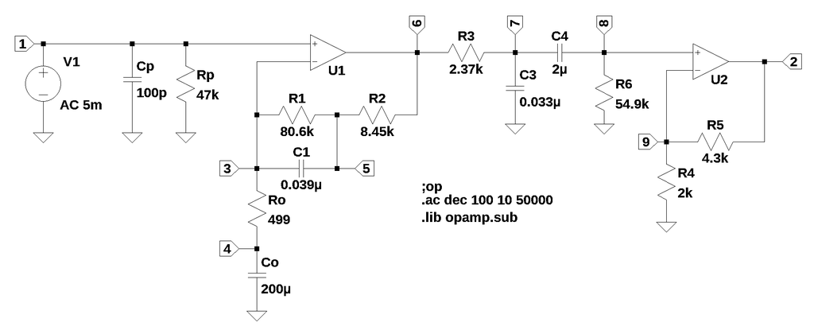

[RIAA](https://en.wikipedia.org/wiki/Recording_Industry_Association_of_America) was formed in 1952. Its original mission was to administer recording copyright fees and problems, work with trade unions, and do research relating to the record industry and government regulations. Early RIAA standards included the RIAA equalization curve, the format of the stereophonic record groove and the dimensions of 33 1/3, 45, and 78 rpm records.

$\large{\color {red} {\text{red note}}}$

[RIAA equalization](https://en.wikipedia.org/wiki/RIAA_equalization) is a specification for the recording and playback of phonograph records, established by the Recording Industry Association of America (RIAA). The purposes of the equalization are to permit greater recording times (by decreasing the mean width of each groove), to improve sound quality and to reduce the groove damage that would otherwise arise during playback. RIAA equalization is a form of pre-emphasis on recording and de-emphasis on playback. A recording is made with the low frequencies reduced and the high frequencies boosted, and on playback, the opposite occurs. The net result is a flat frequency response, but with attenuation of high-frequency noise such as hiss and clicks that arise from the recording medium. Reducing the low frequencies also limits the excursions the cutter needs to make when cutting a groove. Groove width is thus reduced, allowing more grooves to fit into a given surface area, permitting longer recording times. This also reduces physical stresses on the stylus, which might otherwise cause distortion or groove damage during playback.

Phono cartridge output varies depending on the type of phono cartridge. Moving Magnet (MM) or Moving Iron (MI) cartridges typically produce a maximum output of 5mV. Moving Coil (MC) cartridges produce a much lower output, typically around 0.5mV. V1 in the schematic is set to 5mV.

**References:**  
1. [AN-346 High-Performance Audio Applications of the LM833](https://www.ti.com/lit/an/snoa586d/snoa586d.pdf), May 2013, Texas Instruments Incorporated  
2. [LM833 Dual High-Speed Audio Operational Amplifier](https://www.ti.com/lit/ds/symlink/lm833.pdf), July 2010 – revised October 2014

### Python library versions used

- python: 3.10.9
- numpy: 1.23.5
- sympy: 1.11.1
- scipy: 1.10.0
- matplotlib: 3.7.0

```python
import os
from sympy import *
import numpy as np
from scipy import signal
#from sympy.physics.control.lti import TransferFunction, Series, Parallel
#from sympy.physics.control.control_plots import pole_zero_plot, bode_plot
import matplotlib.pyplot as plt
init_printing()
```

### Symbols

The following symbols are used:

| Symbol | defininition |
| --- | --- |
| s | when used in a polynominal: the Laplace variable equal to $\alpha + j\omega$ |
| $\mu s$ | a unit of time: $1 \times 10^{-6}$ seconds |
| H1(s) | RIAA pre-emphsis transfer function, applied during recoding |
| H2(s) | RIAA de-emphsis transfer function, applied during play-back |
| U2(s) | solution of preamplifier circuit network equations, node voltages and unknown currents |
| num | numerator |
| denom | denominator |
| T | time constant: T1, T2, T3 |
| $\omega$ | angular frequency, radians per second, $\omega = 1/T$ |
| f | frequency in cycles per second, $f = \frac{\omega}{2\pi}$ |
| R | resistor: R1, R2 etc. |
| C | capacitor: C1, C2 etc. |
| v | node voltage: v1, v2, v3 etc. |
| V | voltage source, e.g. V1 |
| A | matrix describing the connectivity of the resistors, capacitors and G type (VCCS) circuit elements |
| X | vector of unknown node voltages and unknown currents |
| Z | vector of known voltages and currents |

## 2) RIAA pre-emphasis curve

The RIAA equalization curve was established in 1954. The equalization is defined by time constants, T1, T2 and T3. During the [Phonograph record](https://en.wikipedia.org/wiki/Phonograph_record) manufacturing process, a pre-emphsis is applied to the signal, which allows for longer playback times on phonograph records by decreasing the average width of the groove cut into vinyl phonograph disks. The curve attenuates low frequencies and amplifies high frequencies, relative to 1 kHz. Since low frequencies cause wide undulations in the record groove, they must be attenuated to keep the grove within its bounds. Above 1 kHz, the frequencies are amplified which helps overcome the inherent noise produced by the phonograph needle during play-back.

The RIAA disc recording/reproduction standard specifies the time constants of, $T1 = 75 \mu s$, $T2 = 318 \mu s$ and $T3 = 3180 \mu s$ and the pre-emphasis transfer function:

$H(s)_1=\frac {(sT_{1}+1)(sT_{3}+1)}{(sT_{2}+1)}$

The three time constants correspond to the frequencies calculated below.

```python
T1 = 75e-6
T2 = 318e-6
T3 = 3180e-6
print('{:.0f} \u03BCs corresponds to {:,.1f} Hz'.format(T1*1e6,1/(T1*2*np.pi)))
print('{:.0f} \u03BCs corresponds to {:,.1f} Hz'.format(T2*1e6,1/(T2*2*np.pi)))
print('{:.0f} \u03BCs corresponds to {:,.1f} Hz'.format(T3*1e6,1/(T3*2*np.pi)))
```

```
75 μs corresponds to 2,122.1 Hz
318 μs corresponds to 500.5 Hz
3180 μs corresponds to 50.0 Hz
```

The time constants are put in the s-polynominals for the numerator and denominator of the pre-emphasis transfer function.

```python
s = symbols('s')
H1_num = Eq(((s*T3+1)*(s*T1+1)),0)
H1_denom = Eq(s*T2+1,0)
```

Solve for the poles and zeros of the pre-emphasis transferfunction and plot the locations on the complex s-plane.

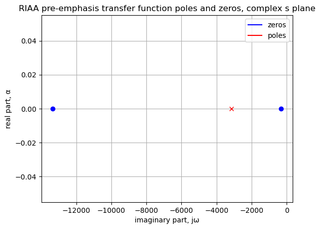

```python
zeros = solve(H1_num,s)
poles = solve(H1_denom,s)

plt.title('RIAA pre-emphasis transfer function poles and zeros, complex s plane')

for i in zeros:
    plt.plot(i, 0, 'ob')
for i in poles:
    plt.plot(i, 0, 'xr')

plt.plot(np.NaN, np.NaN, color='b', label='zeros')
plt.plot(np.NaN, np.NaN, color='r', label='poles')

plt.ylabel('real part, \u03B1')
plt.xlabel('imaginary part, j\u03C9')
plt.legend()
plt.grid()
plt.show()
```

The de-emphisis transfer function of the phono pre-amplifier should have poles at the zero locations and a zero in the pole location in the plot above.

Generate the Bode plot and normalize to 0 dB at 1kHz. During the record manufacturing process, the gains would be adjusted for zero dB at 1kHz, here we simply shift the plot by subtracting 20 dB from the amplitude.

Could rename some variables: - system_1 to system_RIAA - system_2 to system_AN346

$\large{\color {red} {\text{update names?}}}$

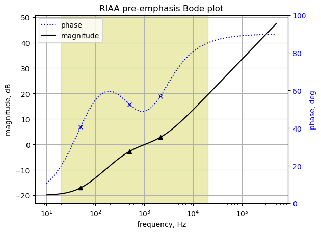

```python
# convert symbolic to numpy polynomial
a = np.array(Poly(H1_num, s).all_coeffs(), dtype=float)
b = np.array(Poly(H1_denom, s).all_coeffs(), dtype=float)
system_1 = signal.TransferFunction(a,b)
#system_1 = (a, b) # system for pre-emphasis transfer function

x_axis_range = np.linspace(10*2*np.pi, 500e3*2*np.pi, 100000, endpoint=True)
w_1, mag_1, phase_1 = system_1.bode(w=x_axis_range) #signal.bode(system_2, w=x_axis_range) # returns: rad/s, mag in dB, phase in deg
#w_1, mag_1, phase_1 = signal.bode(system_1, w=x_axis_range)

fig, ax1 = plt.subplots()
ax1.set_ylabel('magnitude, dB')
ax1.set_xlabel('frequency, Hz')

plt.semilogx(w_1/(2*np.pi), mag_1-20,'-k')    # Bode magnitude plot, normalized to 0 at 1kHz

# mark individual points
p1 = np.where(w_1 > 49.9*(2*np.pi))[0][0]
p2 = np.where(w_1 > 499.9*(2*np.pi))[0][0]
p3 = np.where(w_1 > 2122*(2*np.pi))[0][0]

plt.semilogx(w_1[p1]/(2*np.pi), mag_1[p1]-20,'^k')
plt.semilogx(w_1[p2]/(2*np.pi), mag_1[p2]-20,'^k')
plt.semilogx(w_1[p3]/(2*np.pi), mag_1[p3]-20,'^k')

# hightlight the audio band, 20 to 20kHz
plt.axvspan(20, 20e3, color='y', alpha=0.3)

ax1.tick_params(axis='y')
#ax1.set_ylim((-20,30))
plt.grid()
#plt.legend()

# instantiate a second y-axes that shares the same x-axis
ax2 = ax1.twinx()
plt.semilogx(w_1/(2*np.pi), phase_1,':',color='b',label='phase')  # Bode phase plot

# mark individual points
plt.semilogx(w_1[p1]/(2*np.pi), phase_1[p1],'xb')
plt.semilogx(w_1[p2]/(2*np.pi), phase_1[p2],'xb')
plt.semilogx(w_1[p3]/(2*np.pi), phase_1[p3],'xb')

ax2.set_ylabel('phase, deg',color='b')
ax2.tick_params(axis='y', labelcolor='b')
ax2.set_ylim((0,100))

ax2.plot(np.NaN, np.NaN, color='k', label='magnitude')

plt.legend()
plt.title('RIAA pre-emphasis Bode plot')
plt.show()
```

Is there an implementation of this circuit?

The above looks same as in ref. See if the points 2,122.1 Hz, 500.5 Hz and 50.0 Hz can also be plotted.

Talk about a real pre-emphisis filter since the transfer function is not realizable. How do we know this??

Realisation  
[Network synthesis](https://en.wikipedia.org/wiki/Network_synthesis)  
Given a rational function, it is usually necessary to determine whether the function is realisable as a discrete passive network. All such networks are described by a rational function, but not all rational functions are realisable as a discrete passive network.[10] Historically, network synthesis was concerned exclusively with such networks. Modern active components have made this limitation less relevant in many applications,[11] but at the higher radio frequencies passive networks are still the technology of choice.[12] There is a simple property of rational functions that predicts whether the function is realisable as a passive network. Once it is determined that a function is realisable, there a number of algorithms available that will synthesise a network from it.[13]

[Positive-real function](https://en.wikipedia.org/wiki/Positive-real_function)  
Positive-real functions, often abbreviated to PR function or PRF, are a kind of mathematical function that first arose in electrical network synthesis. They are complex functions, Z(s), of a complex variable, s. A rational function is defined to have the PR property if it has a positive real part and is analytic in the right half of the complex plane and takes on real values on the real axis.

The term positive-real function was originally defined by[1] Otto Brune to describe any function Z(s) which[2]

```
is rational (the quotient of two polynomials),
is real when s is real
has positive real part when s has a positive real part
```

Many authors strictly adhere to this definition by explicitly requiring rationality,[3] or by restricting attention to rational functions, at least in the first instance.[4] However, a similar more general condition, not restricted to rational functions had earlier been considered by Cauer,[1] and some authors ascribe the term positive-real to this type of condition, while others consider it to be a generalization of the basic definition.[4]

Also see https://www.eeeguide.com/positive-real-function/

Also, there is no zero at $j\omega=0$, so the pre-emphisis filter does not block DC.

```python
H1_num
```

$\displaystyle \left(7.5 \cdot 10^{-5} s + 1\right) \left(0.00318 s + 1\right) = 0$

```python
((s*T3+1)*(s*T1+1)).expand()
```

$\displaystyle 2.385 \cdot 10^{-7} s^{2} + 0.003255 s + 1$

```python
((s*T3+1)*(s*T1+1) + (s*T2+1))
```

$\displaystyle 0.000318 s + \left(7.5 \cdot 10^{-5} s + 1\right) \left(0.00318 s + 1\right) + 1$

```python
H1_denom
```

$\displaystyle 0.000318 s + 1 = 0$

```python
H_pre_emp_S = (s*T3+1)*(s*T1+1)/(s*T2+1)
```

```python
H_pre_emp_S
```

$\displaystyle \frac{\left(7.5 \cdot 10^{-5} s + 1\right) \left(0.00318 s + 1\right)}{0.000318 s + 1}$

equ.subs(component_values)

```python
1/(50e3*2*np.pi)
```

$\displaystyle 3.18309886183791 \cdot 10^{-6}$

```python
TX = 3.18309886183791e-6 #7.957747e-6
print('{:.2f} \u03BCs corresponds to {:,.1f} Hz'.format(TX*1e6,1/(TX*2*np.pi)))
```

```
3.18 μs corresponds to 50,000.0 Hz
```

looking at various last poles

```python
T4a = 7.95774715459477e-6 # 20kHz
T4b = 3.18309886183791e-6 # 50kHz

print('T4a: {:.2f} \u03BCs corresponds to {:,.1f} Hz'.format(T4a*1e6,1/(T4a*2*np.pi)))
print('T4b: {:.2f} \u03BCs corresponds to {:,.1f} Hz'.format(T4b*1e6,1/(T4b*2*np.pi)))
```

```
T4a: 7.96 μs corresponds to 20,000.0 Hz
T4b: 3.18 μs corresponds to 50,000.0 Hz
```

```python
#H1_emphasis_tf1_num = Eq(((s*T3+1)*(s*T1+1)),0)
H1a_denom = Eq((s*T2+1)*(s*T4a+1),0)
H1b_denom = Eq((s*T2+1)*(s*T4b+1),0)
```

```python
# convert symbolic to numpy polynomial
a = np.array(Poly(H1_num, s).all_coeffs(), dtype=float)
b = np.array(Poly(H1_denom, s).all_coeffs(), dtype=float)
system_1 = signal.TransferFunction(a,b)
#system_1 = (a, b) # system for pre-emphasis transfer function

x_axis_range = np.linspace(10*2*np.pi, 500e3*2*np.pi, 100000, endpoint=True)
w_1, mag_1, phase_1 = system_1.bode(w=x_axis_range) #signal.bode(system_2, w=x_axis_range) # returns: rad/s, mag in dB, phase in deg
#w_1, mag_1, phase_1 = signal.bode(system_1, w=x_axis_range)
```

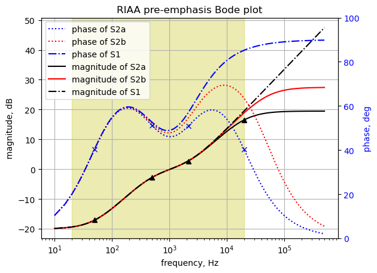

```python
# convert symbolic to numpy polynomial
a1 = np.array(Poly(H1_num, s).all_coeffs(), dtype=float)
b1a = np.array(Poly(H1a_denom, s).all_coeffs(), dtype=float)
b1b = np.array(Poly(H1b_denom, s).all_coeffs(), dtype=float)

#system_1a = (a1, b1a) # system for pre-emphasis transfer function
#system_1b = (a1, b1b) # system for pre-emphasis transfer function

system_1a = signal.TransferFunction(a1,b1a)
system_1b = signal.TransferFunction(a1,b1b)

#x1 = np.linspace(10*2*np.pi, 500e3*2*np.pi, 50000, endpoint=True)
#w_1a, mag_1a, phase_1a = signal.bode(system_1a, w=x_axis_range)
#w_1b, mag_1b, phase_1b = signal.bode(system_1b, w=x_axis_range)

w_1a, mag_1a, phase_1a = system_1a.bode(w=x_axis_range)
w_1b, mag_1b, phase_1b = system_1b.bode(w=x_axis_range)


fig, ax1 = plt.subplots()
ax1.set_ylabel('magnitude, dB')
ax1.set_xlabel('frequency, Hz')

plt.semilogx(w_1a/(2*np.pi), mag_1a-20,'-k')    # Bode magnitude plot, normalized to 0 at ikHz
plt.semilogx(w_1b/(2*np.pi), mag_1b-20,'-r')    # Bode magnitude plot, normalized to 0 at ikHz
plt.semilogx(w_1/(2*np.pi), mag_1-20,'-.k')    # Bode magnitude plot, normalized to 0 at 1kHz

# mark individual points
p1 = np.where(w_1a > 49.9*(2*np.pi))[0][0]
p2 = np.where(w_1a > 499.9*(2*np.pi))[0][0]
p3 = np.where(w_1a > 2122*(2*np.pi))[0][0]
p4 = np.where(w_1a > (1/(T4a*2*np.pi))*(2*np.pi))[0][0]

plt.semilogx(w_1a[p1]/(2*np.pi), mag_1a[p1]-20,'^k')
plt.semilogx(w_1a[p2]/(2*np.pi), mag_1a[p2]-20,'^k')
plt.semilogx(w_1a[p3]/(2*np.pi), mag_1a[p3]-20,'^k')
plt.semilogx(w_1a[p4]/(2*np.pi), mag_1a[p4]-20,'^k')

# hightlight the audio band, 20 to 20kHz
#plt.axvspan(20, 20e3, color='y', alpha=0.25, lw=0)
plt.axvspan(20, 20e3, color='y', alpha=0.3)


ax1.tick_params(axis='y')
#ax1.set_ylim((-20,30))
plt.grid()
#plt.legend()

# instantiate a second y-axes that shares the same x-axis
ax2 = ax1.twinx()
plt.semilogx(w_1a/(2*np.pi), phase_1a,':',color='b',label='phase of S2a')  # Bode phase plot
plt.semilogx(w_1b/(2*np.pi), phase_1b,':',color='r',label='phase of S2b')  # Bode phase plot
plt.semilogx(w_1/(2*np.pi), phase_1,'-.',color='b',label='phase of S1')  # Bode phase plot

# mark individual points
plt.semilogx(w_1a[p1]/(2*np.pi), phase_1a[p1],'xb')
plt.semilogx(w_1a[p2]/(2*np.pi), phase_1a[p2],'xb')
plt.semilogx(w_1a[p3]/(2*np.pi), phase_1a[p3],'xb')
plt.semilogx(w_1a[p4]/(2*np.pi), phase_1a[p4],'xb')

ax2.set_ylabel('phase, deg',color='b')
ax2.tick_params(axis='y', labelcolor='b')
ax2.set_ylim((0,100))

ax2.plot(np.NaN, np.NaN, '-', color='k', label='magnitude of S2a')
ax2.plot(np.NaN, np.NaN, '-', color='r', label='magnitude of S2b')
ax2.plot(np.NaN, np.NaN, '-.', color='k', label='magnitude of S1')

plt.legend(loc=2)
plt.title('RIAA pre-emphasis Bode plot')
plt.show()
```

The existance of these other poles and zeros means that mathematically matcht the inverse transfunct to 0.1 dB is probly not meaningful.

Add hightlights for audio band

Plot error versus T4 and T0 locations.

Probably don;t need to plot impuse and step response.

plt.subplots(1,2,figsize=(15, 5))

# using subplot function and creating

# plot one

plt.subplot(1, 2, 1)

# impulse response

t, y = signal.impulse2(system_petf1a,N=1500) plt.plot(t/1e-3, y) plt.title(‘Impulse response’) plt.ylabel(‘volts’) plt.xlabel(‘time, msec’) plt.grid() plt.xlim((-.001,.050))

# using subplot function and creating plot two

plt.subplot(1, 2, 2)

t, y = signal.step2(system_petf1a,N=1500) plt.plot(t/1e-3, y) plt.title(‘Step response’) plt.ylabel(‘volts’) plt.xlabel(‘time, msec’) plt.grid()

plt.xlim((-.001,.050))

# space between the plots

#plt.tight_layout(4)

# show plot

plt.show()

## 3) AN-346 RIAA Phono Preamplifier Design Procedure

component value calculations …

Even better performance can be obtained by using the two-amplifier approach of Figure 3. The first operational amplifier takes care of the 50 Hz and 500 Hz breakpoints, while the 2122 Hz rolloff is accomplished by the passive network R3, R6, and C3. The second amplifier supplies additional gain—10 dB in this example. Using two amplifiers results in accurate conformance to the RIAA curve without reverting to the noisy inverting topology, as well as lower distortion due to the fact that each amplifier is operating at a lower gain than would be the case in a single-amplifier design. Also, the amplifiers are not required to drive capacitive feedback networks with the full preamplifier output voltages, further reducing distortion compared to the single-amplifier designs.

Also see: Appendix A Derivation of RIAA Phono Preamplifier Design Equation 13, Equation 15, and Equation 16.

Calculations from [1], see page 5 of the app note

1. Choose $R_o$. $R_o$ should be small for minimum noise contribution, but not so small that the feedback network excessively loads the amplifier. Example: Choose $R_o = 500$
2. Choose 1 kHz gain, A1 of first amplifier. This will typically be around 20 dB to 30 dB.Example: Choose AV1 = 26 dB = 20
3. Calculate $R_11 = 8.058 \times R_o \times A_1$

$\large{\color {red} {\text{add narative}}}$

```python
A1 = 20
Ro = 500
R1 = 8.058 * Ro * A1
R1
```

$\displaystyle 80580.0$

4. Calculate C1

$C_1 = \frac {3.18 \times 10^{-3}}{R_1}$

```python
C1 = 3.18e-3/R1 # C1
C1
```

$\displaystyle 3.9463886820551 \cdot 10^{-8}$

5. If C1 is not a convenient value, choose the nearest convenient value and calculate a new R1 from:

$R_1 = \frac {3.18 \times 10^{-3}}{3.9 \times 10^{-8}}$

```python
C1 = 0.039e-6
R1 = 3.18e-3/C1
R1
```

$\displaystyle 81538.4615384615$

```python
R1 = 80.6e3 # use this value
```

Calculate a new value for Ro

$R_o=\frac {R_1}{8.058A_1}$

```python
Ro = R1/(8.058*A1)
Ro
```

$\displaystyle 500.124100273021$

```python
Ro = 499 # use this value
```

6. Caluclate R2  
   $R_2=\frac {R_1}{9} - R_o$

```python
R2 = R1/9-Ro
R2
```

$\displaystyle 8456.55555555555$

```python
R2 = 8.45e3 # use this value
```

7. Choose a convenient value for C3 in the range from 0.01 μF to 0.05 μF.  
   Example: C3 = 0.033 μF

$C_3=7.5 \times 10^{-5} \frac {R_3+R_6}{R_3R6}$

```python
C3 = 0.033e-6
```

8. Calculate Rp  
   $R_p=\frac {7.5 \times 10^{-5}}{C_3}$

```python
Rp = 7.5e-5/C3
Rp
```

$\displaystyle 2272.72727272727$

9. Choose a standard value for R3 that is slightly larger than RP.  
   Example: R3 = 2.37k

```python
R3 = 2.37e3
```

10. Calculate R6 from $1/R_6 = 1/R_P − 1/R_3$

```python
R6 = 1/(1/Rp-1/R3)
R6
```

$\displaystyle 55373.8317757009$

```python
R6 = 54.9e3 # use this value
```

$C_4=\frac{1}{2\pi f_L(R_3+R_6)}$

Where $f_L$ is the low frequency -3dB corner of the second stage.

Example: C4 = 2 μF. Use a good quality mylar, polystyrene, or polypropylene.

```python
f_L = 20.2 # Hz
C4 = 1/(2*np.pi*f_L*(R3+R6))
C4
```

$\displaystyle 1.37575651803854 \cdot 10^{-7}$

12. Choose gain of second amplifier.  
    Example: The 1 kHz gain up to the input of the second amplifier is about 26 dB for this example. For an overall 1 kHz gain equal to about 36 dB we choose:  
    $A_2 = 10 dB = 3.16$
13. Choose value for R4.  
    Example: R4 = 2k

```python
R4 = 2e3
```

14. Calculate $R_5 = (A_2 − 1) R_4$

```python
A2 = 3.16
R5 = (A2-1)*R4
R5
```

$\displaystyle 4320.0$

```python
R5 = 4.3e3 # use this value
```

15. Calculate C0 for low-frequency rolloff below 1 Hz from design Equation 7.  
    Example: Co = 200 μF

```python
fo = 1 # 1 Hz
Co = 1/(2*np.pi*fo*Ro)
Co
```

$\displaystyle 0.000318947781747285$

```python
Co = 200e-6 # use this value
```

### AN-346 phono pre-amp components

Resistors: 1/4W Through Hole Resistor Axial Metal Film  
Capacitors in the audion path: mylar, polystyrene, or polypropylene.

See app note: Selecting Capacitors to Minimize Distortion in Audio Applications

The best capacitor types for audio circuits are polystyrene and polypropylene. Polystyrene is the first choice, but are only available in values up to .001 uF. Above that value, polypropylene is the type of choice, with nearly the same qualities of dissipation factor (DF) and dielectric absorption (DA) as polystyrene (these are the two capacitor “qualities” that most affect audio applications).

Above 50 uF aluminum electrolytic capacitors are a necessary evil. In tube amps electrolytic capacitors are mostly found in the power supply, but are also widely used in the cathode bypass of the power output stage. In Solid State amps, electrolytic types are commonly used everywhere, making this one more reason great sounding tube amps are easier to design.

[output not shown]

Op Amps

| Op Amp | Distortion %, THD + N at 1 kHz | Noise, at 1 kHz (nV√Hz) | Slew Rate, (V/µs) | GBW (MHz) | Open-Loop Gain | Power Bandwidth | Max supply voltage |
| --- | --- | --- | --- | --- | --- | --- | --- |
| LM833N | 0.002 | 4.5 | 7 | 15 | 110 dB (2 kΩ) | 120 kHz @ 27 Vpp, RL = 2 kΩ, THD ≤ 1% | 36 |
| LM4562 | 0.00003 | 2.7 | 20 | 55 | 140dB (600Ω) | 10MHz @ 1VP-P, –3dB, referenced to output magnitude at f = 1kHz | 34 |
| OPA2134 | 0.00008 | 8 | 20 | 8 | 120 dB (600 Ω) | 1.3 MHz | 36 |

## 4) Analysis of AN-346 phono preamplifier circuit

The schematic of the preamp was entered into LTSpice and the netlist was generated. Starting with a schematic and then using LTSpice to generate the net list eliminates errors that would occure if these circuits were analyised by hand. For small circuits with a handful of components, symbolic solutions of the node equations can be of interest, but for larger circuits, not so much.

update description

outline  
- circuit description - MNA - symbolic transfer function - numerical transfer function - plots: pole/zero, Bode, (step impulse ddon;t do these since the Op Amp is ideal), skip group delay

### 4.1) Circuit description

The input is shunted by a capacitance, Cs, which is equal to the sum of the input cable capacitance and the cartridge. This capacitance resonates with the inductance of the moving magnet cartridge around 15 kHz to 20 kHz to determine the frequency response of the transducer, so when a moving magnet pickup is used, Cs should be carefully chosen so that the total capacitance is equal to the recommended load capitance for that particular cartridge. 100 pF is used in this analysis.

### 4.2) Modified nodal analysis

```
* Two amplifier RIAA Phone Preamp v2.asc
V1 1 0 AC 5m
C1 3 5 0.039µ
Co 4 0 200µ
Ro 3 4 499
R3 6 7 2.37k
R1 3 5 80.6k
R2 5 6 8.45k
Cp 1 0 100p
Rp 1 0 47k
C3 7 0 0.033µ
C4 8 7 2µ
R6 8 0 54.9k
R4 9 0 2k
R5 2 9 4.3k
XU1 3 1 6 opamp Aol=100K GBW=10Meg
XU2 9 8 2 opamp Aol=100K GBW=10Meg
;op
.ac dec 100 10 50000
.lib opamp.sub
.backanno
.end
```

The netlist was edited to remove the opamp power connections and the values of the components were converted to exponential notation with units of Ohms, Farads and Henerys. The edited netlist is:

```
* Two amplifier RIAA Phone Preamp v2.asc
V1 1 0 5e-3m
O1 3 1 6
O2 9 8 2
C1 3 5 0.039e-6
Co 4 0 200e-6
Ro 3 4 499
R3 6 7 2.37e3
R1 3 5 80.6e3
R2 5 6 8.45e3
Cp 1 0 100p
Rp 1 0 47e3
C3 7 0 0.033e-6
C4 8 7 2e-6
R6 8 0 54.9e3
R4 9 0 2e3
R5 2 9 4.3e3
;op
.ac dec 100 10 50000
.lib opamp.sub
.backanno
.end
```

This netlist is read into the Symbolic Modified Nodal Analysis Jupyter notebook and the following circuit equations were generated.

```
          ⎛       1 ⎞
I_V1 + v₁⋅⎜Cp⋅s + ──⎟ = 0
          ⎝       Rp⎠
       v₂   v₉
I_O2 + ── - ── = 0
       R₅   R₅
   ⎛       1    1 ⎞      ⎛        1 ⎞   v₄
v₃⋅⎜C₁⋅s + ── + ──⎟ + v₅⋅⎜-C₁⋅s - ──⎟ - ── = 0
   ⎝       Ro   R₁⎠      ⎝        R₁⎠   Ro
   ⎛       1 ⎞   v₃
v₄⋅⎜Co⋅s + ──⎟ - ── = 0
   ⎝       Ro⎠   Ro
   ⎛        1 ⎞      ⎛       1    1 ⎞   v₆
v₃⋅⎜-C₁⋅s - ──⎟ + v₅⋅⎜C₁⋅s + ── + ──⎟ - ── = 0
   ⎝        R₁⎠      ⎝       R₂   R₁⎠   R₂
          ⎛1    1 ⎞   v₇   v₅
I_O1 + v₆⋅⎜── + ──⎟ - ── - ── = 0
          ⎝R₃   R₂⎠   R₃   R₂
              ⎛              1 ⎞   v₆
-C₄⋅s⋅v₈ + v₇⋅⎜C₃⋅s + C₄⋅s + ──⎟ - ── = 0
              ⎝              R₃⎠   R₃
              ⎛       1 ⎞
-C₄⋅s⋅v₇ + v₈⋅⎜C₄⋅s + ──⎟ = 0
              ⎝       R₆⎠
   ⎛1    1 ⎞   v₂
v₉⋅⎜── + ──⎟ - ── = 0
   ⎝R₅   R₄⎠   R₅
v₁ = V₁
-v₁ + v₃ = 0
-v₈ + v₉ = 0
```

Copy the symbols and matrices generated by the modified nodal analysis code.

```python
Rp, v6, Co, C4, v2, C3, s, I_V1, R6, Ro, R4, C1, R3, I_O2, R5, v3, I_O1, v4, v8, v7, V1, Cp, v1, R1, R2, v5, v9 = symbols(' Rp  v6  Co  C4  v2  C3  s  I_V1  R6  Ro  R4  C1  R3  I_O2  R5  v3  I_O1  v4  v8  v7  V1  Cp  v1  R1  R2  v5  v9 ')
A = Matrix([[Cp*s + 1/Rp, 0, 0, 0, 0, 0, 0, 0, 0, 1, 0, 0], [0, 1/R5, 0, 0, 0, 0, 0, 0, -1/R5, 0, 0, 1], [0, 0, C1*s + 1/Ro + 1/R1, -1/Ro, -C1*s - 1/R1, 0, 0, 0, 0, 0, 0, 0], [0, 0, -1/Ro, Co*s + 1/Ro, 0, 0, 0, 0, 0, 0, 0, 0], [0, 0, -C1*s - 1/R1, 0, C1*s + 1/R2 + 1/R1, -1/R2, 0, 0, 0, 0, 0, 0], [0, 0, 0, 0, -1/R2, 1/R3 + 1/R2, -1/R3, 0, 0, 0, 1, 0], [0, 0, 0, 0, 0, -1/R3, C3*s + C4*s + 1/R3, -C4*s, 0, 0, 0, 0], [0, 0, 0, 0, 0, 0, -C4*s, C4*s + 1/R6, 0, 0, 0, 0], [0, -1/R5, 0, 0, 0, 0, 0, 0, 1/R5 + 1/R4, 0, 0, 0], [1, 0, 0, 0, 0, 0, 0, 0, 0, 0, 0, 0], [-1, 0, 1, 0, 0, 0, 0, 0, 0, 0, 0, 0], [0, 0, 0, 0, 0, 0, 0, -1, 1, 0, 0, 0]])
X = Matrix( [v1, v2, v3, v4, v5, v6, v7, v8, v9, I_V1, I_O1, I_O2] )
Z = Matrix( [0, 0, 0, 0, 0, 0, 0, 0, 0, V1, 0, 0] )
```

```python
# modified nodal analysis equations
mna_equ = Eq(A*X,Z)
mna_equ
```

$\displaystyle \left[\begin{matrix}I_{V1} + v_{1} \left(Cp s + \frac{1}{Rp}\right)\\I_{O2} + \frac{v_{2}}{R_{5}} - \frac{v_{9}}{R_{5}}\\v_{3} \left(C_{1} s + \frac{1}{Ro} + \frac{1}{R_{1}}\right) + v_{5} \left(- C_{1} s - \frac{1}{R_{1}}\right) - \frac{v_{4}}{Ro}\\v_{4} \left(Co s + \frac{1}{Ro}\right) - \frac{v_{3}}{Ro}\\v_{3} \left(- C_{1} s - \frac{1}{R_{1}}\right) + v_{5} \left(C_{1} s + \frac{1}{R_{2}} + \frac{1}{R_{1}}\right) - \frac{v_{6}}{R_{2}}\\I_{O1} + v_{6} \cdot \left(\frac{1}{R_{3}} + \frac{1}{R_{2}}\right) - \frac{v_{7}}{R_{3}} - \frac{v_{5}}{R_{2}}\\- C_{4} s v_{8} + v_{7} \left(C_{3} s + C_{4} s + \frac{1}{R_{3}}\right) - \frac{v_{6}}{R_{3}}\\- C_{4} s v_{7} + v_{8} \left(C_{4} s + \frac{1}{R_{6}}\right)\\v_{9} \cdot \left(\frac{1}{R_{5}} + \frac{1}{R_{4}}\right) - \frac{v_{2}}{R_{5}}\\v_{1}\\- v_{1} + v_{3}\\- v_{8} + v_{9}\end{matrix}\right] = \left[\begin{matrix}0\\0\\0\\0\\0\\0\\0\\0\\0\\V_{1}\\0\\0\end{matrix}\right]$

```python
# find symbolic solution
U2 = solve(mna_equ,X)
#U2 # display the results
```

The symbolic solution obtained by SymPy, while not being very interesting since they are unweildly, they illustrate the power of SymPy to easily obtain symbolic solutions that would be very difficult to obtain by hand.

### 4.3) Transfer function

- bode plots
- stability margins

$\large{\color {red} {\text{clean up narrative}}}$

#### Symbolic solution

```python
U2[v1]
```

$\displaystyle V_{1}$

```python
H2 = U2[v2]/U2[v1] # system function
H2 # display the system function
```

$\displaystyle \frac{C_{1} C_{4} Co R_{1} R_{2} R_{4} R_{6} V_{1} s^{3} + C_{1} C_{4} Co R_{1} R_{2} R_{5} R_{6} V_{1} s^{3} + C_{1} C_{4} Co R_{1} R_{4} R_{6} Ro V_{1} s^{3} + C_{1} C_{4} Co R_{1} R_{5} R_{6} Ro V_{1} s^{3} + C_{1} C_{4} R_{1} R_{4} R_{6} V_{1} s^{2} + C_{1} C_{4} R_{1} R_{5} R_{6} V_{1} s^{2} + C_{4} Co R_{1} R_{4} R_{6} V_{1} s^{2} + C_{4} Co R_{1} R_{5} R_{6} V_{1} s^{2} + C_{4} Co R_{2} R_{4} R_{6} V_{1} s^{2} + C_{4} Co R_{2} R_{5} R_{6} V_{1} s^{2} + C_{4} Co R_{4} R_{6} Ro V_{1} s^{2} + C_{4} Co R_{5} R_{6} Ro V_{1} s^{2} + C_{4} R_{4} R_{6} V_{1} s + C_{4} R_{5} R_{6} V_{1} s}{V_{1} \left(C_{1} C_{3} C_{4} Co R_{1} R_{3} R_{4} R_{6} Ro s^{4} + C_{1} C_{3} C_{4} R_{1} R_{3} R_{4} R_{6} s^{3} + C_{1} C_{3} Co R_{1} R_{3} R_{4} Ro s^{3} + C_{1} C_{3} R_{1} R_{3} R_{4} s^{2} + C_{1} C_{4} Co R_{1} R_{3} R_{4} Ro s^{3} + C_{1} C_{4} Co R_{1} R_{4} R_{6} Ro s^{3} + C_{1} C_{4} R_{1} R_{3} R_{4} s^{2} + C_{1} C_{4} R_{1} R_{4} R_{6} s^{2} + C_{1} Co R_{1} R_{4} Ro s^{2} + C_{1} R_{1} R_{4} s + C_{3} C_{4} Co R_{3} R_{4} R_{6} Ro s^{3} + C_{3} C_{4} R_{3} R_{4} R_{6} s^{2} + C_{3} Co R_{3} R_{4} Ro s^{2} + C_{3} R_{3} R_{4} s + C_{4} Co R_{3} R_{4} Ro s^{2} + C_{4} Co R_{4} R_{6} Ro s^{2} + C_{4} R_{3} R_{4} s + C_{4} R_{4} R_{6} s + Co R_{4} Ro s + R_{4}\right)}$

pprint(H)

pprint(H,wrap_line=True)

```python
H2_num, H2_denom = fraction(H2) #returns numerator and denominator
```

```python
H2_num
```

$\displaystyle C_{1} C_{4} Co R_{1} R_{2} R_{4} R_{6} V_{1} s^{3} + C_{1} C_{4} Co R_{1} R_{2} R_{5} R_{6} V_{1} s^{3} + C_{1} C_{4} Co R_{1} R_{4} R_{6} Ro V_{1} s^{3} + C_{1} C_{4} Co R_{1} R_{5} R_{6} Ro V_{1} s^{3} + C_{1} C_{4} R_{1} R_{4} R_{6} V_{1} s^{2} + C_{1} C_{4} R_{1} R_{5} R_{6} V_{1} s^{2} + C_{4} Co R_{1} R_{4} R_{6} V_{1} s^{2} + C_{4} Co R_{1} R_{5} R_{6} V_{1} s^{2} + C_{4} Co R_{2} R_{4} R_{6} V_{1} s^{2} + C_{4} Co R_{2} R_{5} R_{6} V_{1} s^{2} + C_{4} Co R_{4} R_{6} Ro V_{1} s^{2} + C_{4} Co R_{5} R_{6} Ro V_{1} s^{2} + C_{4} R_{4} R_{6} V_{1} s + C_{4} R_{5} R_{6} V_{1} s$

```python
collect((H2_num).expand(),s)
```

$\displaystyle s^{3} \left(C_{1} C_{4} Co R_{1} R_{2} R_{4} R_{6} V_{1} + C_{1} C_{4} Co R_{1} R_{2} R_{5} R_{6} V_{1} + C_{1} C_{4} Co R_{1} R_{4} R_{6} Ro V_{1} + C_{1} C_{4} Co R_{1} R_{5} R_{6} Ro V_{1}\right) + s^{2} \left(C_{1} C_{4} R_{1} R_{4} R_{6} V_{1} + C_{1} C_{4} R_{1} R_{5} R_{6} V_{1} + C_{4} Co R_{1} R_{4} R_{6} V_{1} + C_{4} Co R_{1} R_{5} R_{6} V_{1} + C_{4} Co R_{2} R_{4} R_{6} V_{1} + C_{4} Co R_{2} R_{5} R_{6} V_{1} + C_{4} Co R_{4} R_{6} Ro V_{1} + C_{4} Co R_{5} R_{6} Ro V_{1}\right) + s \left(C_{4} R_{4} R_{6} V_{1} + C_{4} R_{5} R_{6} V_{1}\right)$

```python
solve(H2_num,s)
```

$\displaystyle \left[ 0, \ - \frac{C_{1} R_{1} + Co R_{1} + Co R_{2} + Co Ro}{2 C_{1} Co R_{1} \left(R_{2} + Ro\right)} - \frac{\sqrt{C_{1}^{2} R_{1}^{2} + 2 C_{1} Co R_{1}^{2} - 2 C_{1} Co R_{1} R_{2} - 2 C_{1} Co R_{1} Ro + Co^{2} R_{1}^{2} + 2 Co^{2} R_{1} R_{2} + 2 Co^{2} R_{1} Ro + Co^{2} R_{2}^{2} + 2 Co^{2} R_{2} Ro + Co^{2} Ro^{2}}}{2 C_{1} Co R_{1} \left(R_{2} + Ro\right)}, \ - \frac{C_{1} R_{1} + Co R_{1} + Co R_{2} + Co Ro}{2 C_{1} Co R_{1} \left(R_{2} + Ro\right)} + \frac{\sqrt{C_{1}^{2} R_{1}^{2} + 2 C_{1} Co R_{1}^{2} - 2 C_{1} Co R_{1} R_{2} - 2 C_{1} Co R_{1} Ro + Co^{2} R_{1}^{2} + 2 Co^{2} R_{1} R_{2} + 2 Co^{2} R_{1} Ro + Co^{2} R_{2}^{2} + 2 Co^{2} R_{2} Ro + Co^{2} Ro^{2}}}{2 C_{1} Co R_{1} \left(R_{2} + Ro\right)}\right]$

```python
H2_denom
```

$\displaystyle V_{1} \left(C_{1} C_{3} C_{4} Co R_{1} R_{3} R_{4} R_{6} Ro s^{4} + C_{1} C_{3} C_{4} R_{1} R_{3} R_{4} R_{6} s^{3} + C_{1} C_{3} Co R_{1} R_{3} R_{4} Ro s^{3} + C_{1} C_{3} R_{1} R_{3} R_{4} s^{2} + C_{1} C_{4} Co R_{1} R_{3} R_{4} Ro s^{3} + C_{1} C_{4} Co R_{1} R_{4} R_{6} Ro s^{3} + C_{1} C_{4} R_{1} R_{3} R_{4} s^{2} + C_{1} C_{4} R_{1} R_{4} R_{6} s^{2} + C_{1} Co R_{1} R_{4} Ro s^{2} + C_{1} R_{1} R_{4} s + C_{3} C_{4} Co R_{3} R_{4} R_{6} Ro s^{3} + C_{3} C_{4} R_{3} R_{4} R_{6} s^{2} + C_{3} Co R_{3} R_{4} Ro s^{2} + C_{3} R_{3} R_{4} s + C_{4} Co R_{3} R_{4} Ro s^{2} + C_{4} Co R_{4} R_{6} Ro s^{2} + C_{4} R_{3} R_{4} s + C_{4} R_{4} R_{6} s + Co R_{4} Ro s + R_{4}\right)$

```python
collect((H2_denom).expand(),s)
```

$\displaystyle C_{1} C_{3} C_{4} Co R_{1} R_{3} R_{4} R_{6} Ro V_{1} s^{4} + R_{4} V_{1} + s^{3} \left(C_{1} C_{3} C_{4} R_{1} R_{3} R_{4} R_{6} V_{1} + C_{1} C_{3} Co R_{1} R_{3} R_{4} Ro V_{1} + C_{1} C_{4} Co R_{1} R_{3} R_{4} Ro V_{1} + C_{1} C_{4} Co R_{1} R_{4} R_{6} Ro V_{1} + C_{3} C_{4} Co R_{3} R_{4} R_{6} Ro V_{1}\right) + s^{2} \left(C_{1} C_{3} R_{1} R_{3} R_{4} V_{1} + C_{1} C_{4} R_{1} R_{3} R_{4} V_{1} + C_{1} C_{4} R_{1} R_{4} R_{6} V_{1} + C_{1} Co R_{1} R_{4} Ro V_{1} + C_{3} C_{4} R_{3} R_{4} R_{6} V_{1} + C_{3} Co R_{3} R_{4} Ro V_{1} + C_{4} Co R_{3} R_{4} Ro V_{1} + C_{4} Co R_{4} R_{6} Ro V_{1}\right) + s \left(C_{1} R_{1} R_{4} V_{1} + C_{3} R_{3} R_{4} V_{1} + C_{4} R_{3} R_{4} V_{1} + C_{4} R_{4} R_{6} V_{1} + Co R_{4} Ro V_{1}\right)$

```python
solve(H2_denom,s)
```

$\displaystyle \left[ - \frac{1}{C_{1} R_{1}}, \ - \frac{1}{Co Ro}, \ \frac{- C_{3} R_{3} - C_{4} R_{3} - C_{4} R_{6} - \sqrt{C_{3}^{2} R_{3}^{2} + 2 C_{3} C_{4} R_{3}^{2} - 2 C_{3} C_{4} R_{3} R_{6} + C_{4}^{2} R_{3}^{2} + 2 C_{4}^{2} R_{3} R_{6} + C_{4}^{2} R_{6}^{2}}}{2 C_{3} C_{4} R_{3} R_{6}}, \ \frac{- C_{3} R_{3} - C_{4} R_{3} - C_{4} R_{6} + \sqrt{C_{3}^{2} R_{3}^{2} + 2 C_{3} C_{4} R_{3}^{2} - 2 C_{3} C_{4} R_{3} R_{6} + C_{4}^{2} R_{3}^{2} + 2 C_{4}^{2} R_{3} R_{6} + C_{4}^{2} R_{6}^{2}}}{2 C_{3} C_{4} R_{3} R_{6}}\right]$

The following SymPy code collects and expands the system equation around s.

collect((denom/num).expand(),s)

solve(_,s)

The results above are don’t seem to be particulary insightful, but are easily obtained by SymPy.

#### Numerical solution

The element values are entered into the equations so that a numerical solution can be obtained.

The element values are entered into the equations so that a numerical solution can be obtained.

V1 is 0.018 volts is this the same as -35dBv ??

```python
10*np.log10(0.018)
```

$\displaystyle -17.4472749489669$

```python
20*np.log10(0.018)
```

$\displaystyle -34.8945498979339$

```python
10**(-35/20)
```

$\displaystyle 0.0177827941003892$

```python
10**(-20/10)
```

$\displaystyle 0.01$

```python
# gain of U2, Av = 1 + R5/R4
1+4.3000e+03/2.0000e+03
```

$\displaystyle 3.15$

```python
_*0.018
```

$\displaystyle 0.0567$

V1:1.8000e-02,

but try with V1:1

- component selection
  - Caps
  - resistors
  - op amps
- sensitivity, tolerance and temperature analysis

```python
component_values = {
    V1:5.0000e-03,
    C1:3.9000e-08,
    Co:2.0000e-04,
    Ro:4.9900e+02,
    R3:2.3700e+03,
    R1:8.0600e+04,
    R2:8.4500e+03,
    Cp:1.0000e-10,
    Rp:4.7000e+04,
    C3:3.3000e-08,
    C4:2.0000e-06,
    R6:5.4900e+04,
    R4:2.0000e+03,
    R5:4.3000e+03}
```

```python
# enter the element values
mna_equ_N = mna_equ.subs(component_values)

mna_equ_N  # display the equations
```

$\displaystyle \left[\begin{matrix}I_{V1} + v_{1} \cdot \left(1.0 \cdot 10^{-10} s + 2.12765957446809 \cdot 10^{-5}\right)\\I_{O2} + 0.000232558139534884 v_{2} - 0.000232558139534884 v_{9}\\v_{3} \cdot \left(3.9 \cdot 10^{-8} s + 0.00201641496392288\right) - 0.00200400801603206 v_{4} + v_{5} \left(- 3.9 \cdot 10^{-8} s - 1.24069478908189 \cdot 10^{-5}\right)\\- 0.00200400801603206 v_{3} + v_{4} \cdot \left(0.0002 s + 0.00200400801603206\right)\\v_{3} \left(- 3.9 \cdot 10^{-8} s - 1.24069478908189 \cdot 10^{-5}\right) + v_{5} \cdot \left(3.9 \cdot 10^{-8} s + 0.000130750143157091\right) - 0.000118343195266272 v_{6}\\I_{O1} - 0.000118343195266272 v_{5} + 0.000540284123536314 v_{6} - 0.000421940928270042 v_{7}\\- 2.0 \cdot 10^{-6} s v_{8} - 0.000421940928270042 v_{6} + v_{7} \cdot \left(2.033 \cdot 10^{-6} s + 0.000421940928270042\right)\\- 2.0 \cdot 10^{-6} s v_{7} + v_{8} \cdot \left(2.0 \cdot 10^{-6} s + 1.82149362477231 \cdot 10^{-5}\right)\\- 0.000232558139534884 v_{2} + 0.000732558139534884 v_{9}\\v_{1}\\- v_{1} + v_{3}\\- v_{8} + v_{9}\end{matrix}\right] = \left[\begin{matrix}0\\0\\0\\0\\0\\0\\0\\0\\0\\0.005\\0\\0\end{matrix}\right]$

```python
U2_N = solve(mna_equ_N,X)
U2_N
```

$\displaystyle \left\{ I_{O1} : \frac{- 1.26034548442064 \cdot 10^{69} s^{4} - 7.337901387007 \cdot 10^{72} s^{3} - 2.93150814179881 \cdot 10^{75} s^{2} - 9.87547373027578 \cdot 10^{75} s + 1.43134637756693 \cdot 10^{62}}{2.63366442307692 \cdot 10^{73} s^{4} + 3.60161797332146 \cdot 10^{77} s^{3} + 1.18500865315432 \cdot 10^{80} s^{2} + 2.12690398526132 \cdot 10^{81} s + 9.77609967705846 \cdot 10^{81}}, \ I_{O2} : \frac{- 7.5488731337228 \cdot 10^{51} s^{3} - 2.40350443457901 \cdot 10^{55} s^{2} - 1.34176968067592 \cdot 10^{54} s}{1.31683221153846 \cdot 10^{52} s^{4} + 1.80080898666073 \cdot 10^{56} s^{3} + 5.9250432657716 \cdot 10^{58} s^{2} + 1.06345199263066 \cdot 10^{60} s + 4.88804983852923 \cdot 10^{60}}, \ I_{V1} : - 5.0 \cdot 10^{-13} s - 1.06382978723404 \cdot 10^{-7}, \ v_{1} : 0.005, \ v_{2} : \frac{2.76499422921242 \cdot 10^{69} s^{3} + 8.80353368479522 \cdot 10^{72} s^{2} + 4.91462150480132 \cdot 10^{71} s}{7.65600122987477 \cdot 10^{65} s^{4} + 1.0469819689888 \cdot 10^{70} s^{3} + 3.44479259637884 \cdot 10^{72} s^{2} + 6.18286042227129 \cdot 10^{73} s + 2.84188944100537 \cdot 10^{74}}, \ v_{3} : 0.005, \ v_{4} : \frac{25.0}{499.0 s + 5000.0}, \ v_{5} : \frac{485551950000000.0 s^{2} + 2.51093323715881 \cdot 10^{19} s + 1.54776674937928 \cdot 10^{18}}{9.711039 \cdot 10^{16} s^{2} + 3.1866474317618 \cdot 10^{19} s + 3.09553349875932 \cdot 10^{20}}, \ v_{6} : \frac{2.06102353846154 \cdot 10^{33} s^{2} + 6.56214394746501 \cdot 10^{36} s + 3.66335325296861 \cdot 10^{35}}{2.29847076923077 \cdot 10^{34} s^{2} + 7.54236078523501 \cdot 10^{36} s + 7.3267065059392 \cdot 10^{37}}, \ v_{7} : \frac{9.66255761116519 \cdot 10^{59} s^{3} + 3.085285819805 \cdot 10^{63} s^{2} + 2.81907417491915 \cdot 10^{64} s + 1.56417594832893 \cdot 10^{63}}{8.42772615384614 \cdot 10^{56} s^{4} + 1.15251775146287 \cdot 10^{61} s^{3} + 3.79202769009382 \cdot 10^{63} s^{2} + 6.80609275283623 \cdot 10^{64} s + 3.12835189665871 \cdot 10^{65}}, \ v_{8} : \frac{1.50977462674456 \cdot 10^{55} s^{3} + 4.80700886915802 \cdot 10^{58} s^{2} + 2.68353936135183 \cdot 10^{57} s}{1.31683221153846 \cdot 10^{52} s^{4} + 1.80080898666073 \cdot 10^{56} s^{3} + 5.9250432657716 \cdot 10^{58} s^{2} + 1.06345199263066 \cdot 10^{60} s + 4.88804983852923 \cdot 10^{60}}, \ v_{9} : \frac{1.50977462674456 \cdot 10^{55} s^{3} + 4.80700886915802 \cdot 10^{58} s^{2} + 2.68353936135183 \cdot 10^{57} s}{1.31683221153846 \cdot 10^{52} s^{4} + 1.80080898666073 \cdot 10^{56} s^{3} + 5.9250432657716 \cdot 10^{58} s^{2} + 1.06345199263066 \cdot 10^{60} s + 4.88804983852923 \cdot 10^{60}}\right\}$

num, denom = fraction(u1[v7]) (num/1e43)/(denom/1e43)/V1

Almost all platforms map Python floats to the IEEE754 double precision - 64 total bits. The float information using the sys package can be as shown as follows:

import sys sys.float_info

```python
U2_N[v1] #/V1
```

$\displaystyle 0.005$

```python
H2_N = U2_N[v2]/U2_N[v1]
H2_N
```

$\displaystyle \frac{200.0 \cdot \left(2.76499422921242 \cdot 10^{69} s^{3} + 8.80353368479522 \cdot 10^{72} s^{2} + 4.91462150480132 \cdot 10^{71} s\right)}{7.65600122987477 \cdot 10^{65} s^{4} + 1.0469819689888 \cdot 10^{70} s^{3} + 3.44479259637884 \cdot 10^{72} s^{2} + 6.18286042227129 \cdot 10^{73} s + 2.84188944100537 \cdot 10^{74}}$

#### Normalize coefficients

Extract the numerator and denominator polynomials so that the system can be defined in SciPy.

```python
H2_N_num, H2_N_denom = fraction(H2_N) #returns numerator and denominator
```

```python
H2_N_num
```

$\displaystyle 5.52998845842485 \cdot 10^{71} s^{3} + 1.76070673695904 \cdot 10^{75} s^{2} + 9.82924300960264 \cdot 10^{73} s$

```python
H2_N_num.as_expr().coeff(s**3)
```

$\displaystyle 5.52998845842485 \cdot 10^{71}$

```python
H2_N_denom.as_expr().coeff(s**4)
```

$\displaystyle 7.65600122987477 \cdot 10^{65}$

```python
H2_N_num/H2_N_denom.as_expr().coeff(s**4)
```

$\displaystyle 722307.676342327 s^{3} + 2299773320.42284 s^{2} + 128386121.089526 s$

```python
H2_N_denom/H2_N_denom.as_expr().coeff(s**4)
```

$\displaystyle 1.0 s^{4} + 13675.3108777377 s^{3} + 4499467.14080555 s^{2} + 80758351.9990163 s + 371197620.752192$

```python
(H2_N_num/H2_N_denom.as_expr().coeff(s**4))/(H2_N_denom/H2_N_denom.as_expr().coeff(s**4))
```

$\displaystyle \frac{722307.676342327 s^{3} + 2299773320.42284 s^{2} + 128386121.089526 s}{1.0 s^{4} + 13675.3108777377 s^{3} + 4499467.14080555 s^{2} + 80758351.9990163 s + 371197620.752192}$

```python
solve(H2_N_num,s)
```

$\displaystyle \left[ -3183.86896860174, \ -0.0558265334651996, \ 0.0\right]$

```python
re(solve(H2_N_num,s)[0])/(2*np.pi)
```

$\displaystyle -506.728484509862$

```python
re(solve(H2_N_num,s)[1])/(2*np.pi)
```

$\displaystyle -0.00888506875667163$

```python
re(solve(H2_N_num,s)[2])/(2*np.pi)
```

$\displaystyle 0$

The 506Hz zero is correct, the zeros at −0.00888 and 0 Hz are extra. These are the DC blocking parts of the network.

```python
solve(H2_N_denom,s)
```

$\displaystyle \left[ -13338.433641045 - 1.10200719980902 \cdot 10^{-30} i, \ -318.126868995356 - 3.52548590641477 \cdot 10^{-30} i, \ -10.0200400801603 + 2.68707200346262 \cdot 10^{-30} i, \ -8.73032761723183 + 1.94042110276117 \cdot 10^{-30} i\right]$

```python
re(solve(H2_N_denom,s)[0])/(2*np.pi)
```

$\displaystyle -2122.87764707554$

```python
re(solve(H2_N_denom,s)[1])/(2*np.pi)
```

$\displaystyle -50.6314637309587$

```python
re(solve(H2_N_denom,s)[2])/(2*np.pi)
```

$\displaystyle -1.59473890873643$

```python
re(solve(H2_N_denom,s)[3])/(2*np.pi)
```

$\displaystyle -1.38947479509413$

The 2122 and 50 Hz are correct. the poles at 1.59 and 1.39 are extra.

Looking at the exponents and the degree of the poly, there are extra poles and zeros in the implementation of the filter.

$H(s)_{de-emphasis}=\frac {(sT_{2}+1)}{(sT_{1}+1)(sT_{3}+1)}$

H_demphasis_denom = Eq(((s*T3+1)*(s*T1+1)),0) H_demphasis_num = Eq(s*T2+1,0)

H_demphasis_num

H_demphasis_denom

H_demphasis_denom.expand()

H_demphasis_num.lhs/H_demphasis_denom.expand().lhs

Ideally a 1st order divided by a 2nd order is what we want.

solve(H_demphasis_num,s)[0]/(2*np.pi)

solve(H_demphasis_denom,s)[0]/(2*np.pi)

solve(H_demphasis_denom,s)[1]/(2*np.pi)

H_demphasis = TransferFunction(s*T2+1, ((s*T3+1)*(s*T1+1)), s) # Eq((s*T2+1)/((s*T3+1)*(s*T1+1)),0)

H_demphasis

pole_zero_plot(H_demphasis,show=True)

RIAA playback equalization is not a simple low-pass filter. It defines transition points in three places: 75 μs, 318 μs and 3180 μs, which correspond to 2122 Hz, 500 Hz and 50 Hz. The pre-emphasis transfer function is expressed as follows, where T1=3180 μs, T2=318 μs, etc.:

$f(s)=\frac {(sT_{1}+1)(sT_{3}+1)}{(sT_{2}+1)}$

Zeros: 3183.86896860175

Poles: 318.126868995356,

#### Convert transfer function to SciPy system

```python
# convert symbolic to numpy polynomial
a2 = np.array(Poly(H2_N_num, s).all_coeffs(), dtype=float)
b2 = np.array(Poly(H2_N_denom, s).all_coeffs(), dtype=float)
system_2 = signal.TransferFunction(a2,b2)
```

### 4.4) Pole zero plot

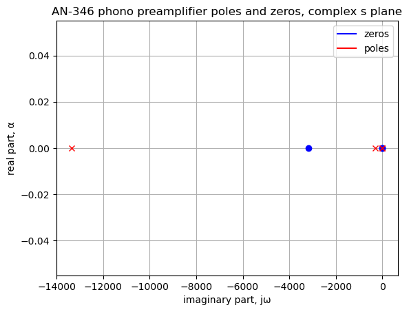

```
number of zeros: 3, number of poles: 4
zeros:  [-3.18386897e+03 -5.58265335e-02  0.00000000e+00]
poles:  [-1.33384336e+04 -3.18126869e+02 -1.00200401e+01 -8.73032762e+00]
```

```python
zeros = np.roots(system_2.num)
poles = np.roots(system_2.den)

plt.title('AN-346 phono preamplifier poles and zeros, complex s plane')

for i in zeros:
    plt.plot(i, 0, 'ob')
for i in poles:
    plt.plot(i, 0, 'xr')

plt.plot(np.NaN, np.NaN, color='b', label='zeros')
plt.plot(np.NaN, np.NaN, color='r', label='poles')

plt.ylabel('real part, \u03B1')
plt.xlabel('imaginary part, j\u03C9')
plt.legend()
plt.grid()
plt.show()

print('number of zeros: {:d}, number of poles: {:d}'.format(len(zeros),len(poles)))
print('zeros: ',zeros)
print('poles: ',poles)
```

### 4.5) Bode plot

Use the SciPy function [bode](https://docs.scipy.org/doc/scipy/reference/generated/scipy.signal.bode.html) to plot the magnitude and phase of the filter.

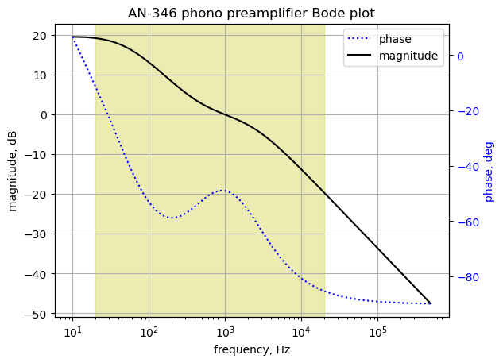

```python
#x = np.linspace(10*2*np.pi, 50e3*2*np.pi, 10000, endpoint=True)
w_2, mag_2, phase_2 = system_2.bode(w=x_axis_range) #signal.bode(system_2, w=x_axis_range) # returns: rad/s, mag in dB, phase in deg

fig, ax1 = plt.subplots()
ax1.set_ylabel('magnitude, dB')
ax1.set_xlabel('frequency, Hz')

#plt.semilogx(w, mag)    # Bode magnitude plot
#plt.plot(w/(2*np.pi*1e6), mag,'-k')    # Bode magnitude plot
#plt.plot(w/(2*np.pi), mag,'-k')    # Bode magnitude plot
plt.semilogx(w_2/(2*np.pi), mag_2-34.8387,'-k')    # Bode magnitude plot

ax1.tick_params(axis='y')
#ax1.set_ylim((-30,20))
#ax1.set_xlim((27e6*2*np.pi,33e6*2*np.pi))
#ax1.set_xlim((27,33))
plt.grid()
plt.axvspan(20, 20e3, color='y', alpha=0.3)

# instantiate a second y-axes that shares the same x-axis
ax2 = ax1.twinx()
color = 'b' #'tab:blue'

#plt.semilogx(w, phase,'-g')  # Bode phase plot
#plt.plot(w/(2*np.pi), phase,':',color=color)  # Bode phase plot
plt.semilogx(w_2/(2*np.pi), phase_2,':',color=color,label='phase')  # Bode phase plot

ax2.set_ylabel('phase, deg',color=color)
ax2.tick_params(axis='y', labelcolor=color)
#ax2.set_ylim((-5,25))
ax2.plot(np.NaN, np.NaN, '-', color='k', label='magnitude')

plt.legend(loc=0)
plt.title('AN-346 phono preamplifier Bode plot')
plt.show()
```

add labels to plot above.

### x.x) Gain and phase margin

w_c1

np.diff(w_c1)

np.gradient(w_c1)

mag_c1

w_c1/(2*np.pi)

np.where(w_c1 > 999.9*2*np.pi)

w_c1[198]/(2*np.pi)

w_c1[199]/(2*np.pi)

mag_c1[199]

mag_c1[198]

phase_c1

In electrical engineering, a [Bode plot](https://en.wikipedia.org/wiki/Bode_plot) is a graph of the frequency response of a system. It is usually a combination of the magnitude (usually in decibels) of the frequency response and the phase shift. As originally conceived by Hendrik Wade Bode in the 1930s, the plot is an asymptotic approximation of the frequency response, using straight line segments. Bode plots are used to assess the stability of systems by finding the gain and phase margins.

```python
# Find neasest position in the array where the value is located
def find_nearest(array,value):
    idx,val = min(enumerate(array), key=lambda x: abs(x[1]-value))
    return idx
```

```python
# gain margin
print('gain margin = {:.2f} dB'.format(mag_2[find_nearest(phase_2, -180)]))
```

```
gain margin = -12.77 dB
```

```python
# phase margin
print('phase margin = {:.2f} deg'.format(phase_2[find_nearest(mag_2, -0.1 )] - (-180)))
```

```
phase margin = 90.82 deg
```

20*np.log10(.1)

10**(-35/20)

gain1 = TransferFunction(-0.0177827941003892,1,s)

tf2a = Series(tf2, gain1)

bode_plot(tf2a,initial_exp=1, final_exp=4,freq_unit=‘Hz’, phase_unit=‘deg’)

H_pre_emp_S H_pre_emp_S = (s*T3+1)*(s*T1+1)/(s*T2+1)

## plot poles and zeros

tf2 = TransferFunction(num, denom, s)

pole_zero_plot(tf1,show=True) pole_zero_plot(tf2,show=True)

S1 = Series(tf1a, tf2a) S1

pole_zero_plot(S1)

bode_plot(S1,initial_exp=1, final_exp=4,freq_unit=‘Hz’, phase_unit=‘deg’)

### 4.6) Impulse and step response

Use the SciPy functions [impulse2](https://docs.scipy.org/doc/scipy/reference/generated/scipy.signal.impulse2.html) and [step2](https://docs.scipy.org/doc/scipy/reference/generated/scipy.signal.step2.html) to plot the impulse and step response of the system.

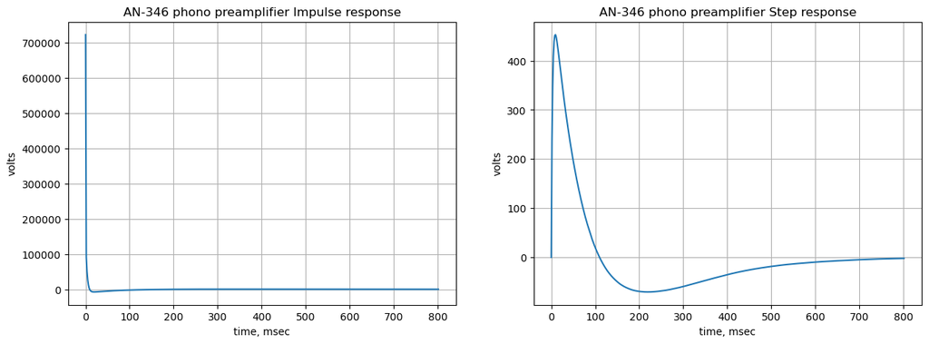

```python
plt.subplots(1,2,figsize=(15, 5))

# using subplot function and creating
# plot one
plt.subplot(1, 2, 1)

# impulse response
t, y = signal.impulse2(system_2,N=500)
plt.plot(t/1e-3, y)
plt.title('AN-346 phono preamplifier Impulse response')
plt.ylabel('volts')
plt.xlabel('time, msec')
plt.grid()

# using subplot function and creating plot two
plt.subplot(1, 2, 2)

t, y = signal.step2(system_2,N=500)
plt.plot(t/1e-3, y)
plt.title('AN-346 phono preamplifier Step response')
plt.ylabel('volts')
plt.xlabel('time, msec')
plt.grid()

# space between the plots
#plt.tight_layout(4)

# show plot
plt.show()
```

The [impulse](https://en.wikipedia.org/wiki/Impulse_response) and [step response](https://en.wikipedia.org/wiki/Step_response) of the filter are plotted above. Any linear, time-invariant is completely characterized by its impulse response. The transfer function is the Laplace transform of the impulse response. The impulse response defines the response of a linear time-invariant system for all frequencies.

In practical systems, it is not possible to produce a perfect impulse to serve as input for testing; therefore, a brief pulse is sometimes used as an approximation of an impulse. Provided that the pulse is short enough compared to the impulse response, the result will be close to the true, theoretical, impulse response.

In electronic engineering and control theory, step response is the time behavior of the outputs of a general system when its inputs change from zero to one in a very short time.

### 4.7) Group delay

The following python code calculates and plots [group delay](https://en.wikipedia.org/wiki/Group_delay_and_phase_delay#). Frequency components of a signal are delayed when passed through a circuit and the signal delay will be different for the various frequencies unless the circuit has the property of being linear phase. The delay variation means that signals consisting of multiple frequency components will suffer distortion because these components are not delayed by the same amount of time at the output of the device.

Group delay: $\tau _{g}(\omega )=-\frac {d\phi (\omega )}{d\omega }$

what are difference between group delay and phase delay

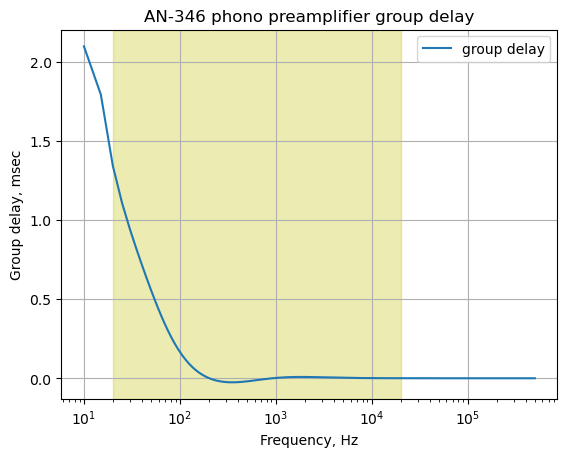

```python
plt.title('AN-346 phono preamplifier group delay')
#plt.semilogx(w_c1/(2*np.pi), -np.gradient(phase_c1)/np.gradient(w_c1)/1e-3,'-',label='group delay')
plt.semilogx(w_2/(2*np.pi), -np.gradient(phase_2)/np.gradient(w_2/(2*np.pi)),'-',label='group delay')
#plt.semilogx(w_c1/(2*np.pi), -np.gradient(phase_c1)/w_c1/1e-3,'-',label='phase delay')
plt.axvspan(20, 20e3, color='y', alpha=0.3)
plt.ylabel('Group delay, msec')
plt.xlabel('Frequency, Hz')
plt.legend()
plt.grid()
plt.show()
```

get data from LTSpice and compare results on a graph. LTSpice runs from 7 to 0 ms.

Seem like need to mult by 20 to get same group delay. Why 20 ??

$\large{\color {red} {\text{add comments about difference}}}$

The results above are don’t seem to be particulary insightful, but are easily obtained by SymPy.

The element values are entered into the equations so that a numerical solution can be obtained.

The plot above shows that for frequencies below 200 Hz, there is a large amount of delay that is frequency dependent. Presumably, the delay compensates for the de-emphases introduced in the record cutting process.

### 4.8) Comparing results to LTSpice

- with LTSpice

/home/jeff64/Documents/Solving Electrical Engineering Problems with Python Blog/MNA Problem Circuits/Two amplifier RIAA Phone Preamp.csv

```python
os.chdir('/home/jeff32/Documents/Solving Electrical Engineering Problems with Python Blog/MNA Problem Circuits/Two amplifier RIAA Phone Preamp/') # change directory to csv file location

fn = 'Two amplifier RIAA Phone Preamp.csv' # data from LTSpice
LTSpice_data = np.genfromtxt(fn, delimiter=',')

# change the working director back to the Jupyter folder
os.chdir('/home/jeff32/Documents/JupyterLab/Node Analysis/')
```

```python
frequency = np.zeros(len(LTSpice_data))
voltage = np.zeros(len(LTSpice_data)).astype(complex)

for i in range(len(LTSpice_data)):
    frequency[i] = LTSpice_data[i][0]
    voltage[i] = LTSpice_data[i][1] + LTSpice_data[i][2]*1j
```

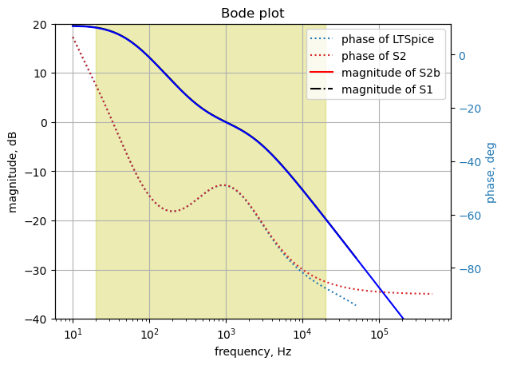

```python
fig, ax1 = plt.subplots()
ax1.set_ylabel('magnitude, dB')
ax1.set_xlabel('frequency, Hz')

plt.semilogx(frequency, 20*np.log10(np.abs(voltage))+11.257,'-k')    # Bode magnitude plot, adding 11.257 dBV offset to normalized LTSpice data at 1KHz
plt.semilogx(w_2/(2*np.pi), mag_2-34.8387,'-b')    # Bode magnitude plot

ax1.tick_params(axis='y')
ax1.set_ylim((-40,20))
plt.grid()
plt.axvspan(20, 20e3, color='y', alpha=0.3)

# instantiate a second y-axes that shares the same x-axis
ax2 = ax1.twinx()
color = 'tab:blue'

plt.semilogx(frequency, np.angle(voltage)*180/np.pi,':',color=color,label='phase of LTSpice')  # Bode phase plot

plt.semilogx(w_2/(2*np.pi), phase_2,':',color='tab:red',label='phase of S2')  # Bode phase plot

ax2.set_ylabel('phase, deg',color=color)
ax2.tick_params(axis='y', labelcolor=color)
#ax2.set_ylim((-5,25))

ax2.plot(np.NaN, np.NaN, '-', color='r', label='magnitude of S2b')
ax2.plot(np.NaN, np.NaN, '-.', color='k', label='magnitude of S1')

plt.legend(loc=0)

plt.title('Bode plot')
plt.show()
```

$\large{\color {red} {\text{comment on difference}}}$

froup delay differences

don’t need the one below

fig, ax1 = plt.subplots() ax1.set_ylabel(‘magnitude, dB’) ax1.set_xlabel(‘frequency, Hz’)

#plt.semilogx(w, mag) # Bode magnitude plot #plt.plot(w/(2*np.pi*1e6), mag,‘-k’) # Bode magnitude plot #plt.plot(w/(2*np.pi), mag,‘-k’) # Bode magnitude plot plt.semilogx(w_1/(2*np.pi), mag_1-20,‘-k’) # Bode magnitude plot plt.semilogx(w_2/(2*np.pi), mag_2-34.8387,‘-b’) # Bode magnitude plot

ax1.tick_params(axis=‘y’) #ax1.set_ylim((-30,20)) #ax1.set_xlim((27e6*2*np.pi,33e6*2*np.pi)) #ax1.set_xlim((27,33)) plt.grid()

# instantiate a second y-axes that shares the same x-axis

ax2 = ax1.twinx() color = ‘tab:blue’

#plt.semilogx(w, phase,‘-g’) # Bode phase plot #plt.plot(w/(2*np.pi), phase,‘:’,color=color) # Bode phase plot plt.semilogx(w_1/(2*np.pi), phase_1,‘:’,color=color) # Bode phase plot plt.semilogx(w_2/(2*np.pi), phase_2,‘:’,color=‘tab:red’) # Bode phase plot

ax2.set_ylabel(‘phase, deg’,color=color) ax2.tick_params(axis=‘y’, labelcolor=color) #ax2.set_ylim((-5,25))

plt.title(‘Bode plot’) plt.show()

### 4.9) Preamplifier deviation from RIAA response

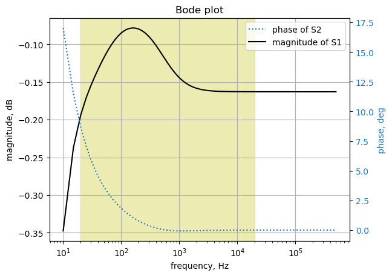

```python
fig, ax1 = plt.subplots()
ax1.set_ylabel('magnitude, dB')
ax1.set_xlabel('frequency, Hz')

#plt.semilogx(w, mag)    # Bode magnitude plot
#plt.plot(w/(2*np.pi*1e6), mag,'-k')    # Bode magnitude plot
#plt.plot(w/(2*np.pi), mag,'-k')    # Bode magnitude plot
plt.semilogx(w_1/(2*np.pi), (mag_1-20) + mag_2-34.8387,'-k')    # Bode magnitude plot
#plt.semilogx(w_c1/(2*np.pi), mag_c1,'-b')    # Bode magnitude plot

ax1.tick_params(axis='y')
#ax1.set_ylim((-30,20))
#ax1.set_xlim((20*2*np.pi,20e3*2*np.pi))
#ax1.set_xlim((27,33))
plt.grid()
plt.axvspan(20, 20e3, color='y', alpha=0.3)

# instantiate a second y-axes that shares the same x-axis
ax2 = ax1.twinx()
color = 'tab:blue'

#plt.semilogx(w, phase,'-g')  # Bode phase plot
#plt.plot(w/(2*np.pi), phase,':',color=color)  # Bode phase plot
plt.semilogx(w_1/(2*np.pi), phase_1+phase_2,':',color=color,label='phase of S2')  # Bode phase plot
#plt.semilogx(w_c1/(2*np.pi), phase_c1,':',color='tab:red')  # Bode phase plot

ax2.set_ylabel('phase, deg',color=color)
ax2.tick_params(axis='y', labelcolor=color)
#ax2.set_ylim((-5,25))
#ax2.set_xlim((20*2*np.pi,20e3*2*np.pi))
ax2.plot(np.NaN, np.NaN, '-', color='k', label='magnitude of S1')
plt.legend(loc=0)

plt.title('Bode plot')
plt.show()
```

$\large{\color {red} {\text{add comments}}}$

Comments:

### 4.10) Implementation considerations

Comments on alternate realization. - LP vinyl source is inherently noisy, don’t need preamp to be 10x better, only blameless - power supply design - choice of OpAmps, Caps and resistors - other filter topologies and transfer functions - info on phono carterages - subsonic filter - limitations of LP vinyl recrodings: [LP record](https://en.wikipedia.org/wiki/LP_record) - don’t need to be better than the source

#### Phonograph record

How is information stored on the medium  
A stereophonic phonograph provides two channels of audio, one left and one right. This is achieved by adding another vertical dimension of movement to the needle in addition to the horizontal one. As a result, the needle now moves not only left and right, but also up and down. But since those two dimensions do not have the same sensitivity to vibration, the difference needs to be evened out by having each channel take half its information from each direction by turning the channels 45 degrees from horizontal.

Vinyl quality

[Phonograph record](https://en.wikipedia.org/wiki/Phonograph_record)

#### Phono carterages

- component selection
  - Caps
  - resistors
  - op amps
- sensitivity, tolerance and temperature analysis

Other links

https://sound-au.com/project27.htm https://sound-au.com/project25.htm https://sound-au.com/project06.htm

## 5) Alternate designs

search for RIAA preamp schematics

https://www.tubecad.com/2020/03/blog0496.htm

Other circuits, See data sheet  
- LM4562, p24 - OP37, fig 8 - LT1115, page 1, fig 4 - has big C to ground - OP27 fig 41 (same as OP37)

### 5.1) circuit 1

### 5.2) circuit 2

### 5.2) circuit N

### 5.X) Filter synthsis from the transfer function

OK, now considering the inverse of the pre-emphis curve.

```python
from sympy.physics.control.lti import TransferFunction, Series, Parallel
from sympy.physics.control.control_plots import pole_zero_plot, bode_plot
```

```python
tf2 = TransferFunction(s*318e-6+1,(s*3180e-6+1)*(s*75e-6+1), s)
tf2
```

$\displaystyle \frac{0.000318 s + 1}{\left(7.5 \cdot 10^{-5} s + 1\right) \left(0.00318 s + 1\right)}$

```python
tf2.expand()
```

$\displaystyle \frac{0.000318 s + 1}{2.385 \cdot 10^{-7} s^{2} + 0.003255 s + 1}$

```python
tf2_expanded = tf2.to_expr().expand()
tf2_expanded
```

$\displaystyle \frac{0.000318 s}{2.385 \cdot 10^{-7} s^{2} + 0.003255 s + 1} + \frac{1}{2.385 \cdot 10^{-7} s^{2} + 0.003255 s + 1}$

See Electronic Filter Design Handbook page 2.4, eq (2-3) for 2nd term and page 5.52 eq (5.89) for 1st term. Synthesis by equating coefficients.

```python
expr1 = tf2_expanded.args[1]
expr1
```

$\displaystyle \frac{0.000318 s}{2.385 \cdot 10^{-7} s^{2} + 0.003255 s + 1}$

```python
expr2 = apart(tf2_expanded.args[0])
expr2
```

$\displaystyle \frac{1.0}{2.385 \cdot 10^{-7} s^{2} + 0.003255 s + 1.0}$

```python
expr1 + expr2
```

$\displaystyle \frac{0.000318 s}{2.385 \cdot 10^{-7} s^{2} + 0.003255 s + 1} + \frac{1.0}{2.385 \cdot 10^{-7} s^{2} + 0.003255 s + 1.0}$

```python
(expr1 + expr2).simplify()
```

$\displaystyle \frac{7.5843 \cdot 10^{-11} s^{3} + 1.27359 \cdot 10^{-6} s^{2} + 0.003573 s + 1.0}{5.68822499999996 \cdot 10^{-14} s^{4} + 1.552635 \cdot 10^{-9} s^{3} + 1.1072025 \cdot 10^{-5} s^{2} + 0.00651 s + 1.0}$

```python
(expr1 + expr2).factor()
```

$\displaystyle \frac{1.0 \cdot \left(7.5843 \cdot 10^{-11} s^{3} + 1.27359 \cdot 10^{-6} s^{2} + 0.003573 s + 1.0\right)}{\left(2.385 \cdot 10^{-7} s^{2} + 0.003255 s + 1.0\right)^{2}}$

```python
(expr1 + expr2).factor().expand()
```

$\displaystyle \frac{7.5843 \cdot 10^{-11} s^{3}}{5.688225 \cdot 10^{-14} s^{4} + 1.552635 \cdot 10^{-9} s^{3} + 1.1072025 \cdot 10^{-5} s^{2} + 0.00651 s + 1.0} + \frac{1.27359 \cdot 10^{-6} s^{2}}{5.688225 \cdot 10^{-14} s^{4} + 1.552635 \cdot 10^{-9} s^{3} + 1.1072025 \cdot 10^{-5} s^{2} + 0.00651 s + 1.0} + \frac{0.003573 s}{5.688225 \cdot 10^{-14} s^{4} + 1.552635 \cdot 10^{-9} s^{3} + 1.1072025 \cdot 10^{-5} s^{2} + 0.00651 s + 1.0} + \frac{1.0}{5.688225 \cdot 10^{-14} s^{4} + 1.552635 \cdot 10^{-9} s^{3} + 1.1072025 \cdot 10^{-5} s^{2} + 0.00651 s + 1.0}$

```python
(expr1 + expr2) #.expand()
```

$\displaystyle \frac{0.000318 s}{2.385 \cdot 10^{-7} s^{2} + 0.003255 s + 1} + \frac{1.0}{2.385 \cdot 10^{-7} s^{2} + 0.003255 s + 1.0}$

```python
(s*318e-6+1)/((s*3180e-6+1)*(s*75e-6+1))
```

$\displaystyle \frac{0.000318 s + 1}{\left(7.5 \cdot 10^{-5} s + 1\right) \left(0.00318 s + 1\right)}$

```python
(s*318e-6+1)/(s*3180e-6+1) #*(1/*(s*75e-6+1)
```

$\displaystyle \frac{0.000318 s + 1}{0.00318 s + 1}$

```python
1/(s*75e-6+1) # This is a high pass section
```

$\displaystyle \frac{1}{7.5 \cdot 10^{-5} s + 1}$

```python
(s*318e-6+1).factor()
```

$\displaystyle 1.0 \cdot \left(0.000318 s + 1.0\right)$

```python
type(H2_N)
```

```
sympy.core.mul.Mul
```

```python
type(tf2)
```

```
sympy.physics.control.lti.TransferFunction
```

```python
system_1 # = signal.TransferFunction(a,b)
```

```
TransferFunctionContinuous(
array([7.50000000e-04, 1.02358491e+01, 3.14465409e+03]),
array([1.00000000e+00, 3.14465409e+03]),
dt: None
)
```

```python
system_1.num # = signal.TransferFunction(a,b)
```

```
array([7.50000000e-04, 1.02358491e+01, 3.14465409e+03])
```

```python
system_2
```

```
TransferFunctionContinuous(
array([7.22307676e+05, 2.29977332e+09, 1.28386121e+08, 0.00000000e+00]),
array([1.00000000e+00, 1.36753109e+04, 4.49946714e+06, 8.07583520e+07,
       3.71197621e+08]),
dt: None
)
```

## 6) Summary

- gain errors don’t agree
- group delay not in agreement

# Links to products

There are hundreds of phon preamps being sold on amazon ranging in price from $10 to $1,000 dollars.

https://www.amazon.com/Pro-Ject-Audio-Phono-preamp-Output/dp/B007DB5I60/ref=sr_1_4?crid=2KH3PW5538BKW&keywords=phono%2Bpre%2Bamp&qid=1700522866&sprefix=phono%2Bpre%2Bamp%2Caps%2C162&sr=8-4&ufe=app_do%3Aamzn1.fos.18630bbb-fcbb-42f8-9767-857e17e03685&th=1

https://www.amazon.com/Cambridge-Audio-Moving-Magnet-Preamplifier/dp/B0793363RG/ref=sr_1_20?crid=2KH3PW5538BKW&keywords=phono+pre+amp&qid=1700522866&sprefix=phono+pre+amp%2Caps%2C162&sr=8-20&ufe=app_do%3Aamzn1.fos.18630bbb-fcbb-42f8-9767-857e17e03685

Mani MM/MC Phono Preamp Finish AC Adapter $149

Input Loading: Selectable R: 47KΩ, 200Ω, 47Ω, or 38Ω Selectable C: 47pF, 100pF, 150pF, or 200pF Low Frequency Filter: 6dB/octave or 12dB/octave at 15 Hz, fully passive

Gain 1 = L, Gain 2 = L (Decca Mode) Gain: 33dB THD: <0.0003%, A-weighted, ref 2V RMS SNR: >108dB, A-weighted, ref 2V RMS Crosstalk: -90dB, 20-20kHz Sensitivity: 5.3mV for 300mV output Overload Margin: >20dB Gain 1 = L, Gain 2 = H (Standard MM Mode) Gain: 42dB THD: <0.0006%, A-weighted, ref 2V RMS SNR: >98dB, A-weighted, ref 2V RMS Crosstalk: -90dB, 20-20kHz Sensitivity: 1.9mV for 300mV output Overload Margin: >20dB

Gain 1 = H, Gain 2 = L (Low Output MM/High Output MC Mode) Gain: 48dB THD: <0.001%, A-weighted, ref 2V RMS SNR: >96dB, A-weighted, ref 2V RMS Crosstalk: -80dB, 20-20kHz Sensitivity: 1.06mV for 300mV output Overload Margin: >20dB

Gain 1 = H, Gain 2 = H (MC Mode) Gain: 60dB THD: <0.0015%, A-weighted, at 2V RMS SNR: >87dB, A-weighted, ref 2V RMS Crosstalk: -75dB, 20-20kHz Sensitivity: 0.33mV for 300mV output Overload Margin: >20dB

So you added a subsonic filter to Mani 2? Er, well, yeah, kinda-sorta. I mean, we could have done a typical subsonic filter with a sharp roll-off, but that would mean running everything through another active stage, and we didn’t like that idea, so we did a 6dB/octave or 12dB/octave passive filter with a shallower roll-off, but which is purely passive—as in, one or two CR pairs in the signal path, that’s it. This was the best trade-off, we believe, between an active subsonic filter or no filter at all. And you can bypass the LF filter entirely on Mani 2—that’s how we ship it from the factory.

Skoll Balanced, Discrete MM/MC Phono Preamp with Remote Control AC Adapter $399

https://www.amazon.com/Pro-Ject-Audio-Phono-Preamplifier-Silver/dp/B008UV5CAY/ref=sr_1_4?crid=2KH3PW5538BKW&keywords=phono+pre+amp&qid=1700523083&sprefix=phono+pre+amp%2Caps%2C162&sr=8-4&ufe=app_do%3Aamzn1.fos.ac578592-0362-4e0a-958c-0f2dd61d30d4 Pro-Ject Phono Box RS Premium MM/MC Phono Preamplifier (Silver)

Audio-Technica AT-LP120XUSB-BK Direct-Drive Turntable (Analog & USB), Fully Manual, Hi-Fi, 3 Speed, Convert Vinyl to Digital, Anti-Skate and Variable Pitch Control Black

https://www.amazon.com/Audio-Technica-AT-LP120XUSB-Direct-Drive-Hi-Fidelity-Anti-Skate/dp/B07N3S4X3P/ref=sr_1_4?crid=3SA39AGHIBPO3&keywords=phono%2Bplayer&qid=1700575696&sprefix=phono%2Bplayer%2Caps%2C144&sr=8-4&ufe=app_do%3Aamzn1.fos.18630bbb-fcbb-42f8-9767-857e17e03685&th=1

https://www.audio-technica.com/en-us/at-vm95c Recommended Load Impedance 47,000 ohms

Moving Coil: Recommended Load Impedance ≥ 100 ohms (when head amplifier connected)

```
1. [SymPy](https://www.sympy.org/), Python library for symbolic mathematics
2. [NumPy](https://numpy.org/), Python library for scientific computing
3. [SciPy](https://scipy.org/), algorithms for scientific computing in Python
4. [Python](https://www.python.org/) [programming language](https://en.wikipedia.org/wiki/Python_(programming_language)), a high-level, general-purpose programming language,
6. [LTSpice](https://www.analog.com/en/design-center/design-tools-and-calculators/ltspice-simulator.html), SPICE ("Simulation Program with Integrated Circuit Emphasis") is a general-purpose, open-source analog electronic circuit simulator from [Analog Devices](https://www.analog.com/en/index.html)
7. [Modified Nodal Analysis](https://en.wikipedia.org/wiki/Modified_nodal_analysis), an extension of nodal analysis which not only determines the circuit's node voltages (as in classical nodal analysis), but also some branch currents
```